# HISTORICAL PLANE CRASHES - A DATA ANALYSIS

### INTRODUCTION

Data science is a "concept to unify statistics, data analysis, machine learning and their related methods" in order to "understand and analyze actual phenomena" with data. It employs various theories and techniques drawn from several fields such as mathematics, information science, statistics, and computer science. The goal of this tutorial is to walk you through the data science pipeline which consists of :

#### Data Curation --> Parsing and Management --> Exploratory Data Analysis --> Hypothesis Testing and Machine Learning to Provide Analysis

#### The Data Set

The data set I will be using is called `planecrashinfo_20181121001952.csv`. The data was collected from http://www.planecrashinfo.com/database.htm. I found the data set on Kaggle and all credits go to the owner. You can download the csv file from https://www.kaggle.com/nguyenhoc/plane-crash. The data set mainly includes:

- Civil/commercial aviation accidents which resulted in fatality
- Cargo and test flight fatal accidents
- Military transportation accidents (with 10 or more fatalities)
- Commerical helicopter accidents (10 or more fatalities)
- Aviation accidents involving the death of famous people
- Aviation accidents or incidents of noteworthy interest  
  Every row in the data set corresponds to a unique historical plane crash. The column features of the data set are explained below:
- Features related to time  
  *Date:* Date of accident, in the format Month DD, YYYY  
  *Time:* Local time in 24 hour format unless otherwise specified
- Features related to the flight  
  *Airline/Op:* Airline or operator of the aircraft  
  *Flight #:* Flight number assigned by the aircraft operator  
  *Route:* Complete or partial route flown prior to the accident  
  *AC Type:* Aircraft type  
  *Reg:* ICAO registration of the aircraft  
  *cn / ln:* Construction or serial number / Line or fuselage number
- Features related to the fatalities  
  *Aboard:* Total number of passengers and crew aboard  
  *Fatalities:* Total fatalities aboard (passengers and crew)  
  *Ground:* Total killed on the ground
- Features related to the event  
  *Summary:* Brief description of the accident and cause if known

#### Getting Started

Before we begin to analyze our data, let's make sure you have all the libraries we need. You have to make sure you have python package manager (pip) installed. Instruction on installation can be found on https://pip.pypa.io/en/stable/installing/ Make sure you have the following packages installed: numpy, pandas, geopy,yellowbrick, folium, sklearn, wordcloud, seaborn, statsmodels, matplotlib. You may use Jupyter notebook's terminal to install all the libraries needed.

#### Importing Packages

```python
import pandas as pd
import numpy as np
import matplotlib.pyplot as plt
import seaborn as sns
import csv
import folium
from datetime import datetime
from geopy.geocoders import Nominatim
from folium.plugins import HeatMap, HeatMapWithTime
from sklearn.feature_extraction import FeatureHasher
from sklearn.model_selection import train_test_split
from sklearn.linear_model import LinearRegression
from sklearn.metrics import mean_squared_error
from yellowbrick.regressor import ResidualsPlot
%matplotlib inline
```

### STEP 1: DATA CURATION

First, let's extract the CSV data.

The dataset consists of 5783 plane crashes. It is important to have a manageable sized data frame. If the dataset you are using is large, you can always trim it accordingly by using just the first x-number of entries.

Let's write a function called read_data that takes the data file path as an argument, uses pandas to read the csv file and outputs the first five entries using head(). The output is our data set in the form of a table with various columns as explained above.

```python
def read_data(data_path=None):
    '''
    return's dataframe from csvfile
    '''
    if data_path is None:
        raise ValueError('Need csv file path as argument !')
    data = pd.read_csv(data_path)
    data = data.copy()
    return data
data = read_data("planecrashinfo_20181121001952.csv")
data.head()
```

|  | date | time | location | operator | flight_no | route | ac_type | registration | cn_ln | aboard | fatalities | ground | summary |
| --- | --- | --- | --- | --- | --- | --- | --- | --- | --- | --- | --- | --- | --- |
| 0 | September 17, 1908 | 17:18 | Fort Myer, Virginia | Military - U.S. Army | ? | Demonstration | Wright Flyer III | ? | 1 | 2 (passengers:1 crew:1) | 1 (passengers:1 crew:0) | 0 | During a demonstration flight, a U.S. Army fly... |
| 1 | September 07, 1909 | ? | Juvisy-sur-Orge, France | ? | ? | Air show | Wright Byplane | SC1 | ? | 1 (passengers:0 crew:1) | 1 (passengers:0 crew:0) | 0 | Eugene Lefebvre was the first pilot to ever be... |
| 2 | July 12, 1912 | 06:30 | Atlantic City, New Jersey | Military - U.S. Navy | ? | Test flight | Dirigible | ? | ? | 5 (passengers:0 crew:5) | 5 (passengers:0 crew:5) | 0 | First U.S. dirigible Akron exploded just offsh... |
| 3 | August 06, 1913 | ? | Victoria, British Columbia, Canada | Private | ? | ? | Curtiss seaplane | ? | ? | 1 (passengers:0 crew:1) | 1 (passengers:0 crew:1) | 0 | The first fatal airplane accident in Canada oc... |
| 4 | September 09, 1913 | c 18:30 | Over the North Sea | Military - German Navy | ? | ? | Zeppelin L-1 (airship) | ? | ? | 20 (passengers:? crew:?) | 14 (passengers:? crew:?) | 0 | The airship flew into a thunderstorm and encou... |

### STEP 2: PARSING AND MANAGEMENT

It is often said that 80% of data analysis is spent on the process of cleaning and preparing the data (*Dasu and Johnson 2003*). "The principles of tidy data provide a standard way to organise data values within a dataset." Cleaning initial data saves us the time to start from scratch. You can find more information about data tidying here: https://vita.had.co.nz/papers/tidy-data.pdf  
We want to select the specific columns that add meaning to our data analysis. We don't necesarily need all the columns, e.g, column cn / ln which represents construction or serial number. We can modify "data" to contain only the columns that we need. Let's select those columns and rename them for ease of understanding and readability. We will remove Reg, cn / ln, flight_no, ground because I don't plan to work with them for this tutorial. Our data should look much cleaner after this step.

```python
# Retrieve desirable columns
column = ['date','time','location','operator','route','ac_type','aboard','fatalities','summary']
data = data[column]

#Rename columns for readability
new_columns = ['date','time','location','operator','route','aircraft_type','aboard','fatalities','description']
data.columns = new_columns

data.head()
```

|  | date | time | location | operator | route | aircraft_type | aboard | fatalities | description |
| --- | --- | --- | --- | --- | --- | --- | --- | --- | --- |
| 0 | September 17, 1908 | 17:18 | Fort Myer, Virginia | Military - U.S. Army | Demonstration | Wright Flyer III | 2 (passengers:1 crew:1) | 1 (passengers:1 crew:0) | During a demonstration flight, a U.S. Army fly... |
| 1 | September 07, 1909 | ? | Juvisy-sur-Orge, France | ? | Air show | Wright Byplane | 1 (passengers:0 crew:1) | 1 (passengers:0 crew:0) | Eugene Lefebvre was the first pilot to ever be... |
| 2 | July 12, 1912 | 06:30 | Atlantic City, New Jersey | Military - U.S. Navy | Test flight | Dirigible | 5 (passengers:0 crew:5) | 5 (passengers:0 crew:5) | First U.S. dirigible Akron exploded just offsh... |
| 3 | August 06, 1913 | ? | Victoria, British Columbia, Canada | Private | ? | Curtiss seaplane | 1 (passengers:0 crew:1) | 1 (passengers:0 crew:1) | The first fatal airplane accident in Canada oc... |
| 4 | September 09, 1913 | c 18:30 | Over the North Sea | Military - German Navy | ? | Zeppelin L-1 (airship) | 20 (passengers:? crew:?) | 14 (passengers:? crew:?) | The airship flew into a thunderstorm and encou... |

#### Missing values and NaN

As we can tell from the above table, there are several missing values. This indicates that the data is either unavailable or has not been collected. These values are treated as noise in the data. For preliminary analysis, I chose to replace all the '?' with NaN and drop all the rows with such values. For extensive analysis, you can adopt imputation of missing values. More information is available on how to do so here: http://www.stat.columbia.edu/~gelman/arm/missing.pdf

```python
#Modifying faulty entries and replacing them to NaN
data = data.replace(to_replace='?', value=np.NaN, inplace=False, limit=None, regex=False, method='pad')
data.head()
```

|  | date | time | location | operator | route | aircraft_type | aboard | fatalities | description |
| --- | --- | --- | --- | --- | --- | --- | --- | --- | --- |
| 0 | September 17, 1908 | 17:18 | Fort Myer, Virginia | Military - U.S. Army | Demonstration | Wright Flyer III | 2 (passengers:1 crew:1) | 1 (passengers:1 crew:0) | During a demonstration flight, a U.S. Army fly... |
| 1 | September 07, 1909 | NaN | Juvisy-sur-Orge, France | NaN | Air show | Wright Byplane | 1 (passengers:0 crew:1) | 1 (passengers:0 crew:0) | Eugene Lefebvre was the first pilot to ever be... |
| 2 | July 12, 1912 | 06:30 | Atlantic City, New Jersey | Military - U.S. Navy | Test flight | Dirigible | 5 (passengers:0 crew:5) | 5 (passengers:0 crew:5) | First U.S. dirigible Akron exploded just offsh... |
| 3 | August 06, 1913 | NaN | Victoria, British Columbia, Canada | Private | NaN | Curtiss seaplane | 1 (passengers:0 crew:1) | 1 (passengers:0 crew:1) | The first fatal airplane accident in Canada oc... |
| 4 | September 09, 1913 | c 18:30 | Over the North Sea | Military - German Navy | NaN | Zeppelin L-1 (airship) | 20 (passengers:? crew:?) | 14 (passengers:? crew:?) | The airship flew into a thunderstorm and encou... |

```python
#Dropping NaN Entries
data = data.dropna()
data = data.reset_index(drop=True)
data.head()
```

|  | date | time | location | operator | route | aircraft_type | aboard | fatalities | description |
| --- | --- | --- | --- | --- | --- | --- | --- | --- | --- |
| 0 | September 17, 1908 | 17:18 | Fort Myer, Virginia | Military - U.S. Army | Demonstration | Wright Flyer III | 2 (passengers:1 crew:1) | 1 (passengers:1 crew:0) | During a demonstration flight, a U.S. Army fly... |
| 1 | July 12, 1912 | 06:30 | Atlantic City, New Jersey | Military - U.S. Navy | Test flight | Dirigible | 5 (passengers:0 crew:5) | 5 (passengers:0 crew:5) | First U.S. dirigible Akron exploded just offsh... |
| 2 | December 14, 1920 | c12:15 | London, England | Handley Page Transport | London - Paris | Handley Page HP-16 | 8 (passengers:6 crew:2) | 4 (passengers:2 crew:2) | The plane failed to gain altitude after taking... |
| 3 | March 22, 1922 | 1140 | North Atlantic Ocean | Aero Limited | Miami - Bimini | Aeromarine Model 85 (flying boat) | 6 (passengers:5 crew:1) | 5 (passengers:5 crew:0) | The plane ditched into the ocean about 40 mile... |
| 4 | April 07, 1922 | 1315 | Grandvilliers, France | Daimler Airways / Grands Express Aeriens | Croydon - Le Bourget | de Havilland DH-18 / Farman F-60 Goliath | 7 (passengers:5 crew:2) | 7 (passengers:5 crew:2) | A midair collision occurred at 400 ft. in poor... |

If you observe the "date" column of our dataset it is in the form Month, Date, Year. To make this more manageable and useful, I chose to split the "date" into three new columns:

- month
- year
- day  
  This will make the data easier to sort while doing Exploratory Data Analysis. I also dropped the original "date" column as it is redundant and holds the same information as our new columns.

```python
#Splitting date into month and year
data['month'], data['year'] = data['date'].str.split(",").str
#Splitting month into month and day
data['month'], data['day'] =  data['month'].str.split(" ").str
#converting to integer type
data['year'] = data['year'].astype(int)
data['day'] = data['day'].astype(int)
#dropping original date column
data.drop(['date'], axis=1, inplace=True)
data.head()
```

|  | time | location | operator | route | aircraft_type | aboard | fatalities | description | month | year | day |
| --- | --- | --- | --- | --- | --- | --- | --- | --- | --- | --- | --- |
| 0 | 17:18 | Fort Myer, Virginia | Military - U.S. Army | Demonstration | Wright Flyer III | 2 (passengers:1 crew:1) | 1 (passengers:1 crew:0) | During a demonstration flight, a U.S. Army fly... | September | 1908 | 17 |
| 1 | 06:30 | Atlantic City, New Jersey | Military - U.S. Navy | Test flight | Dirigible | 5 (passengers:0 crew:5) | 5 (passengers:0 crew:5) | First U.S. dirigible Akron exploded just offsh... | July | 1912 | 12 |
| 2 | c12:15 | London, England | Handley Page Transport | London - Paris | Handley Page HP-16 | 8 (passengers:6 crew:2) | 4 (passengers:2 crew:2) | The plane failed to gain altitude after taking... | December | 1920 | 14 |
| 3 | 1140 | North Atlantic Ocean | Aero Limited | Miami - Bimini | Aeromarine Model 85 (flying boat) | 6 (passengers:5 crew:1) | 5 (passengers:5 crew:0) | The plane ditched into the ocean about 40 mile... | March | 1922 | 22 |
| 4 | 1315 | Grandvilliers, France | Daimler Airways / Grands Express Aeriens | Croydon - Le Bourget | de Havilland DH-18 / Farman F-60 Goliath | 7 (passengers:5 crew:2) | 7 (passengers:5 crew:2) | A midair collision occurred at 400 ft. in poor... | April | 1922 | 7 |

### STEP 3: EXPLORATORY DATA ANALYSIS

Now that we have our data all prepped let us do some analysis. Exploratory Data Analysis (EDA) is an approach for data analysis that makes use of various graphical techniques to maximize insight into a data set. It helps us uncover the underlying structure, extract important variables, detect outliers, test assumptions and more. Plotting raw data in the form of histograms, plotting simple statistics such as box plots, mean, standard deviation are some of the many approaches to EDA. To learn more about EDA, here's a helpful link: http://theta.edu.pl/wp-content/uploads/2012/10/exploratorydataanalysis_tukey.pdf

#### Plane crash occurences over time

For our data, lets first look at occurences of plane crashes over the years. For doing so, we will group the data by "year". Next we want to count the number of crashes that took place in a year, this is simply the number of row entries for a particular year. Once we get the year and count we can use seaborn to plot a barplot that shows Plane crashes vs Year.

```python
# Grouping data by the date
data_crashes_year = data.groupby(['year']).size().reset_index(name='counts')
data_crashes_year.head()
```

|  | year | counts |
| --- | --- | --- |
| 0 | 1908 | 1 |
| 1 | 1912 | 1 |
| 2 | 1920 | 1 |
| 3 | 1922 | 3 |
| 4 | 1923 | 3 |

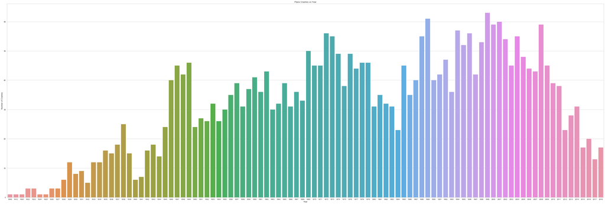

```python
# Graph and label figure
fig, ax = plt.subplots(figsize=(60,20))
sns.barplot(x='year',y='counts',data=data_crashes_year)
plt.title('Plane Crashes vs Year')
plt.ylabel('Number of Crashes')
plt.xlabel('Year')
plt.show()
```

The plot above shows plane crashes over the years. You can zoom on the the graph to see individual years. The years range from 1908 to 2018. The least number of crashes took place during 1908 to 1925. Practically, this makes sense as the first successful airplane was invented on December 17, 1903, by Wilbur and Orville Wright. Planes were first used for passengers in 1914. This explains the number of crashes as there weren't many planes being used to begin with. 1999, 1989 and 2001 were some of the years with the highest number of crashes. It is also interesting to see how the numbers went down after 2011.

Next, let's get a year wise list of fatality counts. We will plot a histogram Fatality vs Year. From the plot we can observe that although 1999 has the highest number of plane crashes, 1985 has the highest fatality count. We can say that on an average there are three "highest-peaks" in the histogram which gives it almost a wave like structure. It looks like fatality count increases, peaks and decreases over time repeatedly.

```python
fatalities_list = []
for index, row in data.iterrows():
    fatalities_list.append(int(row['fatalities'].split(' ')[0]))

#Copying the data set for model analysis
model_data = data

data['fatalities_count'] = pd.Series(fatalities_list).values
data_fatalities_year = data.groupby('year', sort=False)['fatalities_count'].sum().reset_index(name ='fatalities_count')
data_fatalities_year.head()
```

|  | year | fatalities_count |
| --- | --- | --- |
| 0 | 1908 | 1 |
| 1 | 1912 | 5 |
| 2 | 1920 | 4 |
| 3 | 1922 | 17 |
| 4 | 1923 | 63 |

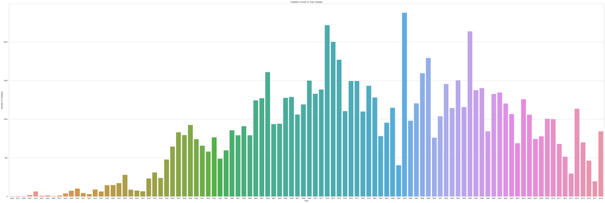

```python
# Graph and label figure
fig, ax = plt.subplots(figsize=(60,20))
sns.barplot(x='year',y='fatalities_count',data=data_fatalities_year)
plt.title('Fatalities Counts vs Year (Global)')
plt.ylabel('Number of Fatalities')
plt.xlabel('Year')
plt.show()
```

#### Data Visualization

To plot data on maps, latitude and longitude coordinates of a location are used. Since our dataset does not contain these specifications, it makes things slightly tricky. But this is a great opportunity to use and learn about Geopy. Geopy makes it easy to locate the coordinates of addresses across the globe using third-party geocoders and other data sources.  
Our data set has location in the form of strings, for example, Atlantic City, New Jersey. We can use geolocate a query to an address and its coordinates. Geolocating "Atlantic City, New Jersey" will give us it's latitude and longitude.  
Each geolocation we use (in our case Nominatim) has its own class in geopy.geocoders abstracting the service’s API.

To learn more about Geopy, it's installation and documentation: https://geopy.readthedocs.io/en/stable/

```python
data = read_data("modified_data.csv")
data.head()
```

|  | Unnamed: 0 | time | location | operator | route | aircraft_type | aboard | fatalities | description | month | year | day | latitude | longitude |
| --- | --- | --- | --- | --- | --- | --- | --- | --- | --- | --- | --- | --- | --- | --- |
| 0 | 2459 | 21:08 | Off Abidjan, Ivory Coast | Kenya Airways | Abidjan - Lagos | AirbusA310-304 | 179 (passengers:169 crew:10) | 169 (passengers:159 crew:10) | The aircraft crashed into the Atlantic Ocean t... | January | 2000 | 30 | 5.320357 | -4.016107 |
| 1 | 350 | 21:14 | Mt. Sanford, Alaska | Northwest Orient Airlines | Anchorage - New York City | Douglas DC-4 (C-54G-1-DO) | 30 (passengers:24 crew:6) | 30 (passengers:24 crew:6) | On a charter flight from Lunghwa Airport, Shan... | March | 1948 | 12 | 62.213889 | -144.128889 |
| 2 | 1341 | 19:30 | Off Saint Thomas, U.S. Virgin Islands | North Cay Airways | Saint Croix - Saint Thomas | Britten-Norman BN-2A Islander | 2 (passengers:1 crew:1) | 2 (passengers:1 crew:1) | Crashed into the ocean. | October | 1974 | 2 | NaN | NaN |
| 3 | 550 | 17:03 | Near Mason City, Iowa | Braniff Airlines | Memphis - Minneapolis | Douglas DC-3 | 19 (passengers:16 crew:3) | 12 (passengers:10 crew:2) | The aircraft crashed 16 miles south of Mason C... | August | 1954 | 22 | NaN | NaN |
| 4 | 2696 | 13:38 | Panama City, Panama | Air Trek | Panama City, Panama - Washington DC | IAI 1124 Westwind | 6 (passengers:4 crew:2) | 6 (passengers:4 crew:2) | After lifting off the runway the air ambulance... | July | 2004 | 2 | 8.971449 | -79.534180 |

#### Heatmaps and Folium

A heatmap is a graphical representation of data. It uses a system of color coding to represent different values. Heatmaps are used in various forms of analytics. They are most commonly used to show user behaviour on specific webpages. Folium is python's wrapper for a tool called leaflet.js. Folium takes in minimal instructions and gives us maps. For our data, we can use folium's heatmap to plot the plane crashes using the coordinates. [0.0,0.0] sets the map to the entire world. The map shows that there have been alot of crashes in/near America and Europe.

```python
heatmap_data = [data['latitude'].dropna(), data['longitude'].dropna()]
heatmap_data = np.rot90(heatmap_data, k=1)
heatmap_data = heatmap_data.tolist()

m = folium.Map([0.0, 0.0], tiles='stamentoner', zoom_start=2.0)
HeatMap(heatmap_data).add_to(m)
m
```

[interactive chart not shown]

To make things more interesting, lets try making a heatmap with respect to time. Let's use months as our time period. First, iterate through the months and plot the [latitute, longitude]. This when done on are larger scale (complete data sets), could give us valuable information. For e.g, Is the number of plane crashes correlated to the month (due to factors such as seasons or weather)? For more information on heatmaps, folium and basics of interative maps: https://www.kaggle.com/daveianhickey/how-to-folium-for-maps-heatmaps-time-data

```python
heatmap_data_month = data.dropna()
map = dict()
for index, row in heatmap_data_month.iterrows():
    if row['month'] in map.keys():
        map[row['month']].append([row['latitude'], row['longitude']])
    else:
        map[row['month']] = [[ row['latitude'], row['longitude']]]

m = folium.Map([0.0, 0.0], tiles='stamentoner', zoom_start=1.7)
HeatMapWithTime(list(map.values()),auto_play=True).add_to(m)
m
```

[interactive chart not shown]

We observed that Americas had the most number of crashes. Let's take a closer look at The U.S.

```python
# US lat long info
top = 49.3457868 # north lat
left = -124.7844079 # west long
right = -66.9513812 # east long
bottom =  24.7433195 # south lat

data = data.dropna()
data = data.loc[(data['latitude'] >= bottom) & (data['latitude'] <= top)]
data = data.loc[(data['longitude'] >= left) & (data['longitude'] <= right)]
heatmap_data_us = [data['latitude'], data['longitude']]
heatmap_data_us = np.rot90(heatmap_data_us, k=1)
heatmap_data_us = heatmap_data_us.tolist()

m = folium.Map([37.0902, -95.7129], tiles='stamentoner', zoom_start=4)
HeatMap(heatmap_data_us).add_to(m)
m
```

[interactive chart not shown]

```python
heatmap_data_month_us = data
map = dict()
for index, row in heatmap_data_month_us.iterrows():
    if row['month'] in map.keys():
        map[row['month']].append([row['latitude'], row['longitude']])
    else:
        map[row['month']] = [[ row['latitude'], row['longitude']]]
m = folium.Map([37.0902, -95.7129], tiles='stamentoner', zoom_start=4)
HeatMapWithTime(list(map.values()),auto_play=True).add_to(m)
m
```

[interactive chart not shown]

### STEP 4: HYPOTHESIS TESTING AND MODEL ANALYSIS

#### Hypothesis

From our priliminary analysis we do not have sufficient evidence to conclude that the number of crashes is related to the year. I believe there might be some correlation between fatality count and one of the following: aircraft_type, route, and/or month. Which will be validated using a linear regression model and plotting residual plot. For linear regression, residual errors follow a normal distribution. Let us look at the number of unique values for each of these. Since the unique counts are very large for aircraft_type and route we need to use hash encoding to avoid overfitting. A useful source on encoding data for categorical variables: https://towardsdatascience.com/smarter-ways-to-encode-categorical-data-for-machine-learning-part-1-of-3-6dca2f71b159  
The number of unique values of month is 12, which is relatively less. For this, we can use one hot encoding.  
More on one hot encoding: https://hackernoon.com/what-is-one-hot-encoding-why-and-when-do-you-have-to-use-it-e3c6186d008f

```python
model_data.columns
len(model_data['aircraft_type'].unique())
```

```
1810
```

```python
len(model_data['route'].unique())
```

```
2963
```

```python
len(model_data['month'].unique()) # since this count is relatively less we can use one hot encoding
```

```
12
```

```python
def one_hot_encoding(data=None, columns=None):
    '''
    one hot encoding for categorical data
    '''
    if data is None or columns is None:
        raise ValueError('Need Data and Columns as arguments !')
    data = data.copy()
    data = pd.concat([data, pd.get_dummies(data=data[columns], columns=columns)], axis=1)
    data.drop(columns, axis=1, inplace=True)
    return data
```

```python
def hash_encoding(data=None, columns=None, n_features=5, input_type='string'):
    '''
     Hash Encoding for categorical data
    '''
    if data is None or columns is None or n_features is None or input_type is None:
        raise ValueError(
            'Need Data, Columns, n_features and  input_type as arguments !')
    data = data.copy()
    hasher = FeatureHasher(n_features, input_type)
    label_1 = [columns[0] + '_' + str(j) for j in range(0, n_features)]
    label_2 = [columns[1] + '_' + str(j) for j in range(0, n_features)]
    hashed = hasher.fit_transform(data[columns[0]])
    df = pd.DataFrame(hashed.toarray(), columns=label_1)
    data = pd.concat([data, df], axis=1)
    data.drop(columns[0], axis=1, inplace=True)
    hashed = hasher.fit_transform(data[columns[1]])
    df = pd.DataFrame(hashed.toarray(), columns=label_2)
    data = pd.concat([data, df], axis=1)
    data.drop(columns[1], axis=1, inplace=True)
    return data
```

The following code divides the data into 70% and 30%. 70% for training data and 30% for testing data. The training set is implemented to build up a model, while a test set is to validate the model that has been built. Data points in the training set are excluded from the test set. A dataset is divided into a testing set and a training set in each iteration.

```python
def split_train_test_data(data=None, y_label=None, test_size=None, random_state=15):
    '''
    spilts data between training and validation and testing
    '''
    if data is None or y_label is None or test_size is None:
        raise ValueError('Need Data, Config map, Test size as arguments !')
    data = data.copy()
    y = data[y_label]
    X = data.drop(y_label, axis=1)
    X_train, X_test, y_train, y_test = train_test_split(X, y, test_size=test_size, random_state=random_state)
    return X_train, y_train, X_test, y_test
```

```python
def calculate_error(X=None, y=None, model=None):
    '''
    returns residual and rmse error for already fit model
    '''
    if X is None or y is None or model is None:
        raise ValueError('Need X, Y, Model as arguments !')
    predictions = model.predict(X)
    mse = mean_squared_error(y, predictions)
    rmse = np.sqrt(mse)
    return rmse
```

```python
def residual_plot(X_train=None, y_train=None, X_test=None, y_test=None):
    if X_train is None or y_train is None or X_test is None or y_test is None:
        raise ValueError('Need X_train, y_train, X_test, y_test as arguments !')
    model = LinearRegression(n_jobs=-1)
    visualizer = ResidualsPlot(model)
    visualizer.fit(X_train.values, y_train.values)
    visualizer.score(X_test.values, y_test.values)
    visualizer.poof()
    return None
```

```python
model_data = model_data[['month', 'route', 'aircraft_type', 'fatalities_count']]
model_data = one_hot_encoding(model_data, 'month')
model_data = hash_encoding(model_data, ["route", "aircraft_type"])
X_train, y_train, X_test, y_test = split_train_test_data(model_data, 'fatalities_count', 0.3)
```

```python
#Model training
model = LinearRegression(n_jobs=-1)
model.fit(X_train, y_train)
training_rmse = calculate_error(X_train, y_train, model)
print ("training error")
print(training_rmse)
testing_rmse = calculate_error(X_test, y_test, model)
print ("testing error")
print(testing_rmse)
```

```
training error
40.285542716453186
testing error
40.12117695336304
```

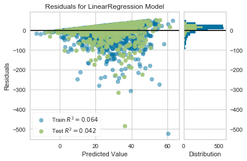

```python
#Residual Plot
residual_plot(X_train, y_train, X_test, y_test)
```

#### References

Historical Plane Crashes: https://www.kaggle.com/nguyenhoc/plane-crash  
Pandas documentation: https://pandas.pydata.org/pandas-docs/stable/generated/pandas.DataFrame.html  
Folium documentation: https://folium.readthedocs.io/en/latest/  
Numpy Polyfit: https://docs.scipy.org/doc/numpy/reference/generated/numpy.polyfit.html  
Sckit Learn: http://scikit-learn.org/stable/modules/generated/sklearn.model_selection.KFold.html.